# Lab Notebook

2018-07-03

linkedin badge

[Richard Careaga](https://www.linkedin.com/in/richardcareaga?trk=profile-badge)

2018-07-06 MCA

Correspondence analysis detail (perf/kcluster independent)

```
library(tidyverse)
library(DBI)
library(RMySQL)
library(FactoMineR)
drv <- dbDriver("MySQL")
con <- dbConnect(drv, username="root", password="", dbname ="dlf", host="localhost")
res <- dbGetQuery(con, "SELECT * from loans_bak")
cs <- as.tibble(res)
load("data/kmeans_loans.Rda") # brings in cs.k
#check for missing values
nrow(cs) == length(cs.k$cluster)
# convert to data frame
csk <- as.tibble(cs.k$cluster)
# rename the column
csk <- csk %>% transmute(kcluster = value)
# combine
loans <- bind_cols(cs,csk)
# remove duplicate rownames column
loans <- loans[-1]
# write back to SQL
#dbWriteTable(con, "loans", loans)
# test
#dbGetQuery(con, "SELECT * from loans limit 25")
cs <- as.tibble(dbGetQuery(con, "SELECT perf, kcluster from loans"))
#xtbl <- table(loans$perf, loans$kcluster) # interesting 3 clusters quite distinct
xtbl <- table(cs$perf,cs$kcluster)
round(prop.table(xtbl),3)
#§ 2.6 Hassan et Pags
res.test.chi2 <- chisq.test(xtbl)
round(res.test.chi2$expected,1)
round(res.test.chi2$residuals^2,2)
round(100*res.test.chi2$residuals^2/res.test.chi2$stat,2)
ddd <- rbind(xtbl,apply(xtbl[,1:3],2,sum))
rownames(ddd)[4] <- "Mean profile"
round(prop.table(as.matrix(ddd),margin=1),3)
ddd <- cbind(xtbl,apply(xtbl[,1:3],2,sum))
colnames(ddd)[4] <- "Mean profile"
round(prop.table(as.matrix(ddd),margin=2),3)
res.ca <- CA(xtbl[,1:3])

par(mfrow=c(2,2))
plot(res.ca, invisible = "col")
coord.col = sweep(res.ca$col$coord,2,sqrt(res.ca$eig[1]), FUN="*")
points(coord.col,pch=17,col="red")
text(coord.col,rownames(coord.col), col="red")
plot(res.ca, invisible = "row")
coord.row = sweep(res.ca$row$coord,2,sqrt(res.ca$eig[1]), FUN="*")
points(coord.row,pch=17,col="red")
text(coord.row,rownames(coord.row), col="red")

summary(res.ca)

barplot(res.ca$eig[,1],main="Eigenvalues", names.arg=1:nrow(res.ca$eig))

res.ca$row$inertia/res.ca$call$marge.row
res.ca$col$inertia/res.ca$call$marge.col
```

2018-07-05

Time to add cluster results to db

Just in case:

```
MariaDB [dlf]> CREATE TABLE loans_bak AS SELECT * from loans;
Query OK, 96147 rows affected (1.06 sec)
Records: 96147  Duplicates: 0  Warnings: 0
```

Strategy is to create df loans w/all fields and cbind cs.k$clusters, renam “value” to kcluster and write back to loans, after dropping it

```
dbWriteTable(con, "loans", cs)
```

Here’s the code (not run, to avoid churn)

```
library(tidyverse)
library(DBI)
library(RMySQL)
library(FactoMineR)

drv <- dbDriver("MySQL")
con <- dbConnect(drv, username="root", password="", dbname ="dlf", host="localhost")
res <- dbGetQuery(con, "SELECT * from loans_bak")
cs <- as.tibble(res)
load("data/kmeans_loans.Rda") # brings in cs.k
#check for missing values
nrow(cs) == length(cs.k$cluster)
# convert to data frame
csk <- as.tibble(cs.k$cluster)
# rename the column
csk <- csk %>% transmute(kcluster = value)
# combine
loans <- bind_cols(cs,csk)
# remove duplicate rownames column
loans <- loans[-1]
# write back to SQL
#dbWriteTable(con, "loans", loans)
# test
#dbGetQuery(con, "SELECT * from loans limit 25")
```

```
    1     2     3
```

A 0.004 0.003 0.002 B 0.265 0.512 0.089 C 0.038 0.074 0.013

```
      1       2      3
```

A 261.9 502.9 89.2 B 25550.8 49063.4 8706.7 C 3671.3 7049.7 1251.0

```
     1      2      3
```

A 30.33 106.92 228.38 B 0.06 0.56 1.87 C 0.72 0.62 0.18

```
    1     2     3
```

A 8.20 28.93 61.79 B 0.02 0.15 0.51 C 0.19 0.17 0.05 1 2 3 A 0.411 0.317 0.272 B 0.306 0.591 0.103 C 0.302 0.594 0.103 Mean profile 0.307 0.589 0.104 1 2 3 Mean profile A 0.012 0.005 0.023 0.307 B 0.865 0.870 0.854 0.589 C 0.123 0.126 0.123 0.104

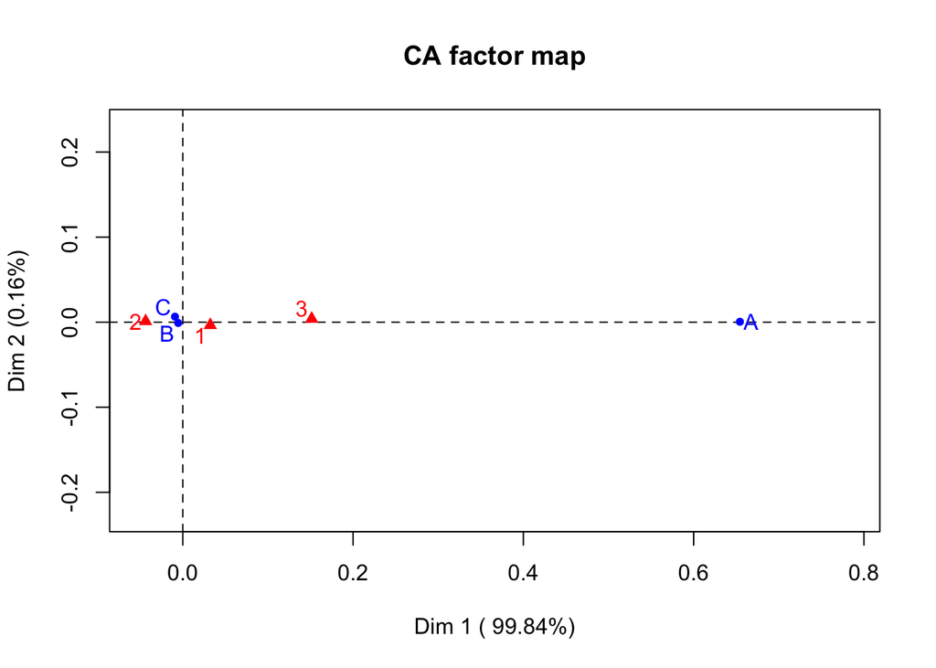

Call: CA(X = xtbl[, 1:3])

The chi square of independence between the two variables is equal to 369.6315 (p-value = 1.010684e-78 ).

Eigenvalues Dim.1 Dim.2 Variance 0.004 0.000 % of var. 99.843 0.157 Cumulative % of var. 99.843 100.000

Rows Iner*1000 Dim.1 ctr cos2 Dim.2 ctr cos2  
A | 3.803 | 0.654 99.071 1.000 | 0.001 0.041 0.000 | B | 0.026 | -0.005 0.654 0.970 | -0.001 12.686 0.030 | C | 0.016 | -0.009 0.275 0.667 | 0.007 87.273 0.333 |

Columns Iner*1000 Dim.1 ctr cos2 Dim.2 ctr cos2  
1 | 0.323 | 0.032 8.331 0.989 | -0.003 61.004 0.011 | 2 | 1.124 | -0.044 29.273 0.999 | 0.001 11.842 0.001 | 3 | 2.397 | 0.151 62.397 0.999 | 0.004 27.154 0.001 | A B C 4.281293e-01 2.986792e-05 1.270018e-04 1 2 3 0.001054728 0.001909367 0.022935527

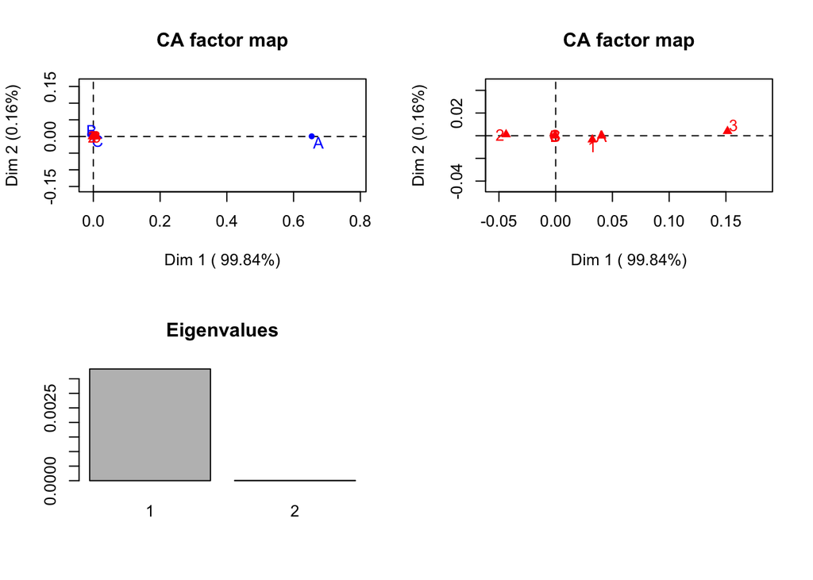

2018-07-03

# Add kmeans clusters

load(“data/kmeans_loans.Rda”) # after setwd() # object is cs.k check for missing values > nrow(cs) == length(cs.k$cluster) [1] TRUE

*But* do we know that they are in the same order?

Docs suggest so:

```
kmeans returns an object of class "kmeans" which has a print and a fitted method. It is a list with at least the following components:
cluster - A vector of integers (from 1:k) indicating the cluster to which each point is allocated
```

## Use of PCA

Per https://goo.gl/4aLdxY (MITxPRO), you use the number of PCs to the slope as the k parameter is all

So, let’s try that. k is *centers*

Uh, oh. *orate* isn’t really continuous, is it? Neither is *cltv* but taking it out degrades the clustering

# set.seed

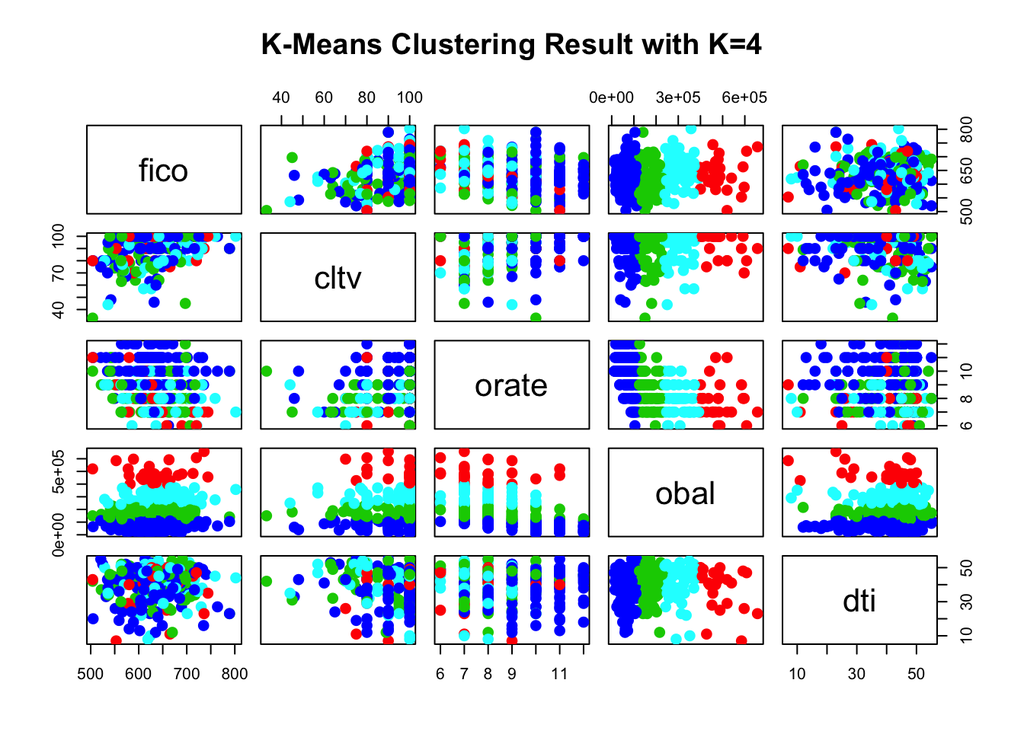

So, today, we did k-means clustering. Possible next step, use clusters for logistic regression against category (eliminate A?) or go to MCA.

Keywords to cover and index

R Python MySQL Unsupervised machine learning Supervised machine learding OLR GLM or flexible Lasso Ridge NLP NLTK Stochastic Variational Inference LDA Latent Dirichlet Allocation Baysian Neutral networks Feature extraction Perceptrons Support Vector Machines Penalized LR Random Forests Trees Boosted Trees Cross validation Deep learning ANOVA Time series GIS Spark Hadoop Gradient boosting

# Missing skills

- Consider Tableau: $70/month https://goo.gl/NbGBht
- Practice BI: https://goo.gl/BeHaUs
- Practice Azure:

# Eye Candy

linkedin badge

[Richard Careaga](https://www.linkedin.com/in/richardcareaga?trk=profile-badge)

## date: ‘2018-07-01’

# runs.test: Is it even worthwhile pursuing with all the NaNs?

## date: 2018-06-30

# Runs tests

**Next up**

Create a column to summarize p.value

Question: Why the NaNs? Need to scan binreps to visually inspect?

# Fall of FICO

date: 2018-06-28

PCA allows categorical variables, as well as numeric. We have a ton of those. FAMD function in FactoMineR

Location: 5-digit zip too small as a market proxy, metro too big; use 3-digit zip:

```
select round(zip/100,0) from y6c
```

categorical, how to prevent auto scaling just make them character

- dtype
- fpd
- ltype
- ptype
- pmi
- ppp
- purpose
- ptype
- otype
- performance category
- origination grade
- 3digitzip

# refactor dataset

```
library(tidyverse)
library(DBI)
library(RMySQL)
drv <- dbDriver("MySQL")
con <- dbConnect(drv, username="root", password="", dbname ="dlf", host="localhost")
res <- dbGetQuery(con, "SELECT ctapeno, deal, remit, fico, dti, cltv, orate, obal grade, round(zip/100,0), dtype, fpd,ltype, pmiflag, ppp, otype, purpose, ptype FROM y6c")
cs <- as.tibble(res)
require(binaryLogic)
require(stringi)
reports <- cs %>% rowwise %>% mutate(repbin = toString(as.binary(remit))) %>% rowwise %>% mutate(repstr = str_replace_all(repbin,"[, ]",'')) %>% mutate(reports = str_count(repstr)) %>% select(ctapeno, repstr, reports)
perf <- reports %>% mutate(category = case_when(str_detect(repstr, '111$') ~ "C", str_count(repstr, '0') <= 9 ~ "B", str_count(repstr, '0') > 9 ~ "A")) %>% select(ctapeno, category)
y6rf <- cs %>% inner_join(perf, by = "ctapeno")
#y6rf = y6 refactored
y6rf <- y6rf %>% mutate(zip = as.character(`round(zip/100,0)`), pmiflag = as.character(pmiflag), ppp = as.character(ppp), perf = category)
y6rf <- y6rf %>% select(ctapeno, deal,fico,dti,cltv,orate, grade, dtype,fpd,ltype, pmiflag, ppp,  otype, purpose, ptype, zip, perf)
dbWriteTable(con, "loans", y6rf)
# test
# res <- dbGetQuery(con, "SELECT * from loans limit 25") passed
```

# Merge tapes

date: 2018-06-27

Combined y6 and y7 to consolidate fields into y6c (which has y7 data by addition of fields)

Origination numeric fields (plus fpd, not yet taken):

dti, cltv, orate, ltv, obal use as pc to predict “down”, maybe throw in fico as a lagniappe

“SELECT fico, dti, cltv, orate, obal FROM y6c”

Problem: still not sure what P1 … P5 represent. 2018-07-06 ok, got it, plane through n-space minimizing residuals ~ lm

Let’s do pairwise OLS lm first

How about cov?

> cov(scaly) fico dti cltv orate obal down fico 1.00000000 -0.03594626 0.29570774 -0.18935765 0.10728314 -0.04441833 dti -0.03594626 1.00000000 0.12124129 -0.07629329 0.11736560 0.02532160 cltv 0.29570774 0.12124129 1.00000000 0.17115040 -0.07890685 0.12093407 orate -0.18935765 -0.07629329 0.17115040 1.00000000 -0.45150260 0.11757547 obal 0.10728314 0.11736560 -0.07890685 -0.45150260 1.00000000 0.06891944 down -0.04441833 0.02532160 0.12093407 0.11757547 0.06891944 1.00000000

```
> cor(scaly)
             fico         dti        cltv       orate        obal        down
fico   1.00000000 -0.03594626  0.29570774 -0.18935765  0.10728314 -0.04441833
dti   -0.03594626  1.00000000  0.12124129 -0.07629329  0.11736560  0.02532160
cltv   0.29570774  0.12124129  1.00000000  0.17115040 -0.07890685  0.12093407
orate -0.18935765 -0.07629329  0.17115040  1.00000000 -0.45150260  0.11757547
obal   0.10728314  0.11736560 -0.07890685 -0.45150260  1.00000000  0.06891944
down  -0.04441833  0.02532160  0.12093407  0.11757547  0.06891944  1.00000000
>
```

# PCA pricipal components

> r <- prcomp(scaly)

```
> r
Standard deviations (1, .., p=6):
[1] 1.2523144 1.1503207 1.0457500 0.9812385 0.7564960 0.6926491

Rotation (n x k) = (6 x 6):
             PC1         PC2         PC3         PC4        PC5        PC6
fico  -0.2726069 0.568920661 -0.47632326  0.11276894  0.4755543 -0.3691371
dti   -0.1710298 0.215539163  0.55919570 -0.71903668  0.2849873 -0.1155868
cltv   0.1376170 0.745824779 -0.02405669 -0.09615915 -0.5261476  0.3716859
orate  0.6811577 0.095976905  0.08191957 -0.02775104 -0.1778098 -0.6983662
obal  -0.6340908 0.005058523  0.24268157  0.20396340 -0.5331799 -0.4616569
down   0.1069994 0.253732918  0.62787932  0.64703296  0.3160727  0.1066990
```

> summary(result.pca)

```
Call:
PCA(X = result)


Eigenvalues
                       Dim.1   Dim.2   Dim.3   Dim.4   Dim.5   Dim.6
Variance               1.566   1.290   1.131   0.954   0.562   0.497
% of var.             26.095  21.508  18.843  15.892   9.375   8.288
Cumulative % of var.  26.095  47.603  66.445  82.337  91.712 100.000

Individuals (the 10 first)
          Dist    Dim.1    ctr   cos2    Dim.2    ctr   cos2    Dim.3    ctr   cos2
1     |  3.273 |  0.226  0.003  0.005 | -2.569  0.511  0.616 |  0.921  0.075  0.079 |
2     |  1.752 | -0.992  0.063  0.321 |  0.813  0.051  0.216 |  0.156  0.002  0.008 |
3     |  3.504 |  1.888  0.228  0.290 | -2.466  0.471  0.495 | -0.053  0.000  0.000 |
4     |  2.965 |  0.790  0.040  0.071 |  0.999  0.077  0.113 |  1.192  0.126  0.162 |
5     |  3.460 | -1.356  0.118  0.154 | -2.739  0.581  0.627 |  0.578  0.030  0.028 |
6     |  3.264 | -1.380  0.122  0.179 |  0.763  0.045  0.055 |  1.981  0.347  0.368 |
7     |  1.599 |  0.040  0.000  0.001 |  0.629  0.031  0.155 | -0.072  0.000  0.002 |
8     |  3.289 | -2.299  0.338  0.489 | -0.143  0.002  0.002 |  2.255  0.450  0.470 |
9     |  4.524 | -2.889  0.533  0.408 | -3.371  0.881  0.555 |  0.164  0.002  0.001 |
10    |  2.062 |  1.657  0.175  0.646 | -0.228  0.004  0.012 | -0.298  0.008  0.021 |

Variables
         Dim.1    ctr   cos2    Dim.2    ctr   cos2    Dim.3    ctr   cos2
fico  |  0.499 15.884  0.249 |  0.567 24.919  0.322 | -0.411 14.926  0.169 |
dti   |  0.278  4.925  0.077 |  0.213  3.515  0.045 |  0.519 23.840  0.270 |
cltv  |  0.096  0.588  0.009 |  0.876 59.465  0.767 |  0.082  0.589  0.007 |
orate | -0.804 41.294  0.647 |  0.272  5.727  0.074 |  0.167  2.467  0.028 |
obal  |  0.764 37.288  0.584 | -0.269  5.606  0.072 |  0.263  6.141  0.069 |
down  | -0.018  0.022  0.000 |  0.100  0.768  0.010 |  0.767 52.036  0.588 |
>

    > lapply(dimdesc(result.pca), lapply, round,2)
$Dim.1
$Dim.1$quanti
      correlation p.value
obal         0.76       0
fico         0.50       0
dti          0.28       0
```

[output cut: 9 more lines]

```
orate        0.27       0
dti          0.21       0
down         0.10       0
obal        -0.27       0


$Dim.3
$Dim.3$quanti
      correlation p.value
down         0.77    0.00
dti          0.52    0.00
obal         0.26    0.00
orate        0.17    0.00
cltv         0.08    0.01
fico        -0.41    0.00
```

date: ‘2018-06-26’

# Notes on covariance of categorical variables

Cross tab of risk categories and performance categories (as.table).

```
 A~B, A~C, B~C, A~B+C cov()?
```

1. Convert to % (function or matrix)
2. Compare to Y7 as a whole
3. Measure ’r, $delta$` between %age in Y7 and d/f categories

   ```
            A     B     C
    A       4  2125   317
    A-      1   648   100
    A+      3  2712   381
    AA      0     1     0
    AP     35 18971  2654
    AP+     0   781    97
    B       1   687    95
    B-      0     1     0
    B+      0   547    66
    C       2   865   125
   ```

   From the [LBMLT 2006-1](https://goo.gl/756A4w) pro supp @ *Underwriting of the Mortgage Loans* (incomplete description)

> Risk Categories

```
Under the sponsor's underwriting programs, various risk categories are used to grade the likelihood that the prospective borrower will satisfy the repayment conditions of the mortgage loan.  These risk categories establish the maximum permitted loan-to-value ratio and loan amount, given the occupancy status of the mortgaged property and the prospective borrower's credit history and debt ratio.

Mortgage loans are originated under the sponsor's underwriting guidelines using the following categories and criteria for grading the potential likelihood that a prospective borrower will satisfy the repayment obligations of a mortgage loan:

Credit Grade:  "Premium A".  Under the "Premium A" risk category, the prospective borrower must have a credit report reflecting a one year credit history and a prior mortgage or rental history evidencing no 30-day late payments during the last 12 months.  No notice of default filings or foreclosures may have occurred during the preceding 36 months.  No open lawsuits are permitted; however, the prospective borrower may be a plaintiff in a lawsuit if a reasonable explanation is provided.  Maximum qualifying debt service-to-income ratio is 55.  A maximum loan-to-value ratio of 100% is permitted for owner occupied single-family, two-unit and condominium properties, a maximum loan-to-value ratio of 95% is permitted for second homes, and a maximum loan-to-value ratio of 85% is permitted for owner occupied mortgage properties consisting of three-to-four units.  A maximum loan-to-value ratio of 90% is permitted for non-owner occupied single-family, two-unit and condominium properties, and a maximum loan-to-value ratio of 80% is permitted for non-owner occupied properties consisting of three-to-four units.

Credit Grade:  "A".  Under the "A" risk category, a maximum of one 30-day late payment within the last 12 months is permitted on an existing mortgage loan.  A maximum of one rolling 30-day late payment is allowed.  No notice of default filings or foreclosures may have occurred during the preceding 36 months.  The mortgaged property must be in at least average condition.  A maximum loan-to-value ratio of 100% is permitted for owner occupied single-family, two-unit and condominium properties, a maximum loan-to-value ratio of 95% is permitted for second homes, and a maximum loan-to-value ratio of 85% is permitted for owner occupied mortgaged properties consisting of three-to-four units.  A maximum loan-to-value ratio of 90% is permitted for non-owner occupied single-family, two-unit and condominium properties, and a maximum loan-to-value ratio of 80% is permitted for non-owner occupied mortgaged properties consisting of three-to-four units.  Generally, the debt service-to-income ratio maximum may be 55% based on the prospective borrower's net disposable income and if the loan-to-value ratio is less than or equal to 90%.  In addition, the prospective borrower must have a credit score of 500 or higher (550 or higher for interest only mortgage loans).

Credit Grade:  "A‑".  Under the "A‑" risk category, a maximum of two 30-day late payments within the last 12 months is permitted on an existing mortgage loan.  A maximum of two rolling 30-day late payments is allowed.  No notice of default filings or foreclosures may have occurred during the preceding 36 months.  The mortgaged property must be in at least average condition.  A maximum loan-to-value ratio of 95% is permitted for owner occupied single-family, two-unit and condominium properties, a maximum loan-to-value ratio of 90% is permitted for second homes, and a maximum loan-to-value ratio of 85% is permitted for owner occupied mortgaged properties consisting of three-to-four units.  A maximum loan-to-value ratio of 90% is permitted for non-owner occupied single-family, two-unit and condominium properties, and a maximum loan-to-value ratio of 80% is permitted for non-owner occupied mortgaged properties consisting of three-to-four units.  Generally, the debt service-to-income ratio maximum may be 55% based on the prospective borrower's net disposable income and if the loan-to-value ratio is less than or equal to 90%.  In addition, the prospective borrower must have a credit score of 500 or higher (550 or higher for interest only mortgage loans).

Credit Grade:  "B+".  Under the "B+" risk category, a maximum of three 30-day late payments within the last 12 months is permitted on an existing mortgage loan.  No notice of default filings or foreclosures may have occurred during the preceding 24 months.  The mortgaged property must be in at least average condition.  A maximum loan-to-value ratio of 95% is permitted for owner occupied single-family, two-unit and condominium properties, a maximum loan-to-value ratio of 90% is permitted for second homes, and a maximum loan-to-value ratio of 85% is permitted for owner occupied mortgaged properties consisting of three-to-four units.  A maximum loan-to-value ratio of 90% is permitted for non-owner occupied single-family, two-unit and condominium properties, and a maximum loan-to-value ratio of 80% is permitted for non-owner occupied mortgaged properties consisting of three-to-four units.  Generally, the debt service-to-income ratio must be 55% or less based on the prospective borrower's net disposable income and/or loan-to-value ratio.  In addition, the prospective borrower must have a credit score of 500 or higher (550 or higher for interest only mortgage loans).

Credit Grade:  "B".  Under the "B" risk category, a maximum of one 60-day late payment within the last 12 months is permitted on an existing mortgage loan.  No notice of default filings or foreclosures may have occurred during the preceding 18 months.  The mortgaged property must be in at least average condition.  A maximum loan-to-value ratio of 90% is permitted for owner occupied single-family, two-unit and condominium properties, a maximum loan-to-value ratio of 85% is permitted for second homes, and a maximum loan-to-value ratio of 80% is permitted for owner occupied mortgaged properties consisting of three-to-four units.  A maximum loan-to-value ratio of 85% is permitted for non-owner occupied single-family, two-unit and condominium properties, and a maximum loan-to-value ratio of 75% is permitted for non-owner occupied mortgaged properties consisting of three-to-four units.  Generally, the debt service-to-income ratio must be 55% or less based on the prospective borrower's net disposable income and/or loan-to-value ratio.  In addition, the prospective borrower must have a credit score of 500 or higher (550 or higher for interest only mortgage loans).

Credit Grade:  "C".  Under the "C" risk category, the prospective borrower may have experienced significant credit problems in the past.  A maximum of four 60-day late payments and no 90-day late payments, or three 60-day late payments and one 90-day late payment, or if the loan-to-value ratio does not exceed 70%, two 90-day late payments and one 120-day late payment, within the last 12 months is permitted on an existing mortgage loan.  No notice of default filings or foreclosures may have occurred during the preceding 12 months.  The mortgaged property must be in at least average condition.  A maximum loan-to-value ratio of 85% is permitted for owner occupied single-family, two-unit and condominium properties, a maximum loan-to-value ratio of 80% is permitted for second homes, and a maximum loan-to-value ratio of 75% is permitted for owner occupied mortgaged properties consisting of three-to-four units.  A maximum loan-to-value ratio of 80% is permitted for non-owner occupied single-family, two-unit and condominium properties, and a maximum loan-to-value ratio of 70% is permitted for non-owner occupied mortgaged properties consisting of three-to-four units.  Generally, the debt service-to-income ratio must not exceed 55%.
```